# Implementing Naive Bayes Algorithms

Using Bank Loan Dataset

Sophia Tang Hart

February 2022

# OBJECTIVE AND DATA DESCRIPTION

**Background:**

Banks loan out money to customers to finance a car, a house, pay for education, consolidate loans, etc. Borrowers agree to pay back the money with an interest on a monthly basis. Sometimes, due to unexpected circumstances, some borrowers are not able to pay back the money.

**Research Objectives:**

The banks would want to see what is the pattern in the customers to predict if a customer can pay back the loan, so the bank knows who to lend out the money. I would like to predict if any customer goes to a bank, should the bank loan out the money to the customer base on model learned from this dataset.

**Research Questions:**

1. What factors contribute/correlated most to bank loan status?
2. Can we predict if a borrower will be able to pay the debt in full?
3. What Machine Learning algorithms perform best in the prediction? (First Guess)
4. Optimize all (or the best) algorithms. With the fine tuned hyperparameters, what is the best prediction performance? Which algorithm?

**Dataset**

The dataset is taken from Kaggle (https://www.kaggle.com/zaurbegiev/my-dataset). There are over 100,000 rows and 19 columns (features) in this dataset. The predicted feature variable is Loan_Status, which is a categorical variable with value either “Fully Paid” or “Charged off”. Fully Paid means the borrower can pay back the debt, while charged off means the borrower is unlikely pay the bank after a substantial delinquent for a period of time. The remainder of the debt is sometimes collected by a third-party agency.

LoanID,

CustomerID,

Loan_Status,

Current_Loan_Amount,

Term,

Credit_Score,

Annual_Income,

Years_in_current_job,

Home_Ownership,

Purpose,

Monthly_Debt,

Years_of_Credit_History,

Months_since_last_delinquent,

Number_of_Open_Accounts,

Number_of_Credit_Problems,

Current_Credit_Balance,

Maximum_Open_Credit,

Bankruptcies,

Tax_Liens

# STEP 1: LOADING LIBRARIES AND DATA

```r
library(caret)
library(dplyr)
library(tidyverse)
library(mlbench)
#library(gmodels)
# for multiple plots in one figure (ggarrange)
library(ggpubr)
library(ggplot2)
library(lattice)

library(naivebayes)
```

## Examing data

```r
# Clear memory
rm(list=ls())

# read in data
BankLoan_dataset <- read.csv("LoanStatus.csv")

# remove unrelevant fields
BankLoan_dataset <- subset(BankLoan_dataset, select=-c(LoanID, CustomerID))

# data structure
knitr::kable(str(BankLoan_dataset))
```

```
## 'data.frame':    100000 obs. of  17 variables:
##  $ Loan_Status                 : chr  "Fully Paid" "Fully Paid" "Fully Paid" "Fully Paid" ...
##  $ Current_Loan_Amount         : int  445412 262328 99999999 347666 176220 206602 217646 648714 548746 215952 ...
##  $ Term                        : chr  "Short Term" "Short Term" "Short Term" "Long Term" ...
##  $ Credit_Score                : int  709 NA 741 721 NA 7290 730 NA 678 739 ...
##  $ Annual_Income               : int  1167493 NA 2231892 806949 NA 896857 1184194 NA 2559110 1454735 ...
##  $ Years_in_current_job        : chr  "8 years" "10+ years" "8 years" "3 years" ...
##  $ Home_Ownership              : chr  "Home Mortgage" "Home Mortgage" "Own Home" "Own Home" ...
##  $ Purpose                     : chr  "Home Improvements" "Debt Consolidation" "Debt Consolidation" "Debt Consolidation" ...
##  $ Monthly_Debt                : num  5215 33296 29201 8742 20640 ...
##  $ Years_of_Credit_History     : num  17.2 21.1 14.9 12 6.1 17.3 19.6 8.2 22.6 13.9 ...
##  $ Months_since_last_delinquent: int  NA 8 29 NA NA NA 10 8 33 NA ...
##  $ Number_of_Open_Accounts     : int  6 35 18 9 15 6 13 15 4 20 ...
##  $ Number_of_Credit_Problems   : int  1 0 1 0 0 0 1 0 0 0 ...
##  $ Current_Credit_Balance      : int  228190 229976 297996 256329 253460 215308 122170 193306 437171 669560 ...
##  $ Maximum_Open_Credit         : int  416746 850784 750090 386958 427174 272448 272052 864204 555038 1021460 ...
##  $ Bankruptcies                : int  1 0 0 0 0 0 1 0 0 0 ...
##  $ Tax_Liens                   : int  0 0 0 0 0 0 0 0 0 0 ...
```

[output not shown]

```r
# data summary
knitr::kable(head(BankLoan_dataset))
```

| Loan_Status | Current_Loan_Amount | Term | Credit_Score | Annual_Income | Years_in_current_job | Home_Ownership | Purpose | Monthly_Debt | Years_of_Credit_History | Months_since_last_delinquent | Number_of_Open_Accounts | Number_of_Credit_Problems | Current_Credit_Balance | Maximum_Open_Credit | Bankruptcies | Tax_Liens |
| --- | --- | --- | --- | --- | --- | --- | --- | --- | --- | --- | --- | --- | --- | --- | --- | --- |
| Fully Paid | 445412 | Short Term | 709 | 1167493 | 8 years | Home Mortgage | Home Improvements | 5214.74 | 17.2 | NA | 6 | 1 | 228190 | 416746 | 1 | 0 |
| Fully Paid | 262328 | Short Term | NA | NA | 10+ years | Home Mortgage | Debt Consolidation | 33295.98 | 21.1 | 8 | 35 | 0 | 229976 | 850784 | 0 | 0 |
| Fully Paid | 99999999 | Short Term | 741 | 2231892 | 8 years | Own Home | Debt Consolidation | 29200.53 | 14.9 | 29 | 18 | 1 | 297996 | 750090 | 0 | 0 |
| Fully Paid | 347666 | Long Term | 721 | 806949 | 3 years | Own Home | Debt Consolidation | 8741.90 | 12.0 | NA | 9 | 0 | 256329 | 386958 | 0 | 0 |
| Fully Paid | 176220 | Short Term | NA | NA | 5 years | Rent | Debt Consolidation | 20639.70 | 6.1 | NA | 15 | 0 | 253460 | 427174 | 0 | 0 |
| Charged Off | 206602 | Short Term | 7290 | 896857 | 10+ years | Home Mortgage | Debt Consolidation | 16367.74 | 17.3 | NA | 6 | 0 | 215308 | 272448 | 0 | 0 |

```r
knitr::kable(summary(BankLoan_dataset))
```

|  | Loan_Status | Current_Loan_Amount | Term | Credit_Score | Annual_Income | Years_in_current_job | Home_Ownership | Purpose | Monthly_Debt | Years_of_Credit_History | Months_since_last_delinquent | Number_of_Open_Accounts | Number_of_Credit_Problems | Current_Credit_Balance | Maximum_Open_Credit | Bankruptcies | Tax_Liens |
| --- | --- | --- | --- | --- | --- | --- | --- | --- | --- | --- | --- | --- | --- | --- | --- | --- | --- |
|  | Length:100000 | Min. : 10802 | Length:100000 | Min. : 585 | Min. : 76627 | Length:100000 | Length:100000 | Length:100000 | Min. : 0 | Min. : 3.6 | Min. : 0.0 | Min. : 0.00 | Min. : 0.0000 | Min. : 0 | Min. :0.000e+00 | Min. :0.0000 | Min. : 0.00000 |
|  | Class :character | 1st Qu.: 179652 | Class :character | 1st Qu.: 705 | 1st Qu.: 848844 | Class :character | Class :character | Class :character | 1st Qu.: 10214 | 1st Qu.:13.5 | 1st Qu.: 16.0 | 1st Qu.: 8.00 | 1st Qu.: 0.0000 | 1st Qu.: 112670 | 1st Qu.:2.734e+05 | 1st Qu.:0.0000 | 1st Qu.: 0.00000 |
|  | Mode :character | Median : 312246 | Mode :character | Median : 724 | Median : 1174162 | Mode :character | Mode :character | Mode :character | Median : 16220 | Median :16.9 | Median : 32.0 | Median :10.00 | Median : 0.0000 | Median : 209817 | Median :4.679e+05 | Median :0.0000 | Median : 0.00000 |
|  | NA | Mean :11760447 | NA | Mean :1076 | Mean : 1378277 | NA | NA | NA | Mean : 18472 | Mean :18.2 | Mean : 34.9 | Mean :11.13 | Mean : 0.1683 | Mean : 294637 | Mean :7.608e+05 | Mean :0.1177 | Mean : 0.02931 |
|  | NA | 3rd Qu.: 524942 | NA | 3rd Qu.: 741 | 3rd Qu.: 1650663 | NA | NA | NA | 3rd Qu.: 24012 | 3rd Qu.:21.7 | 3rd Qu.: 51.0 | 3rd Qu.:14.00 | 3rd Qu.: 0.0000 | 3rd Qu.: 367959 | 3rd Qu.:7.830e+05 | 3rd Qu.:0.0000 | 3rd Qu.: 0.00000 |
|  | NA | Max. :99999999 | NA | Max. :7510 | Max. :165557393 | NA | NA | NA | Max. :435843 | Max. :70.5 | Max. :176.0 | Max. :76.00 | Max. :15.0000 | Max. :32878968 | Max. :1.540e+09 | Max. :7.0000 | Max. :15.00000 |
|  | NA | NA | NA | NA’s :19154 | NA’s :19154 | NA | NA | NA | NA | NA | NA’s :53141 | NA | NA | NA | NA’s :2 | NA’s :204 | NA’s :10 |

# STEP 2: DATA PREPROCESSING

## a) Convert to numeric values

```r
BankLoan_dataset$Years_in_current_job = extract_numeric(BankLoan_dataset$Years_in_current_job)
BankLoan_dataset$Years_in_current_job <- as.numeric(BankLoan_dataset$Years_in_current_job)
```

## b) Convert Categorical Variables

## d) Remove Null

```r
# # identify outliers
# outliers <- boxplot(BankLoan_dataset$Annual_Income, plot=FALSE)$out
# # remove outliers
# BankLoan_dataset <- BankLoan_dataset[-which(BankLoan_dataset$Annual_Income %in% outliers), ]
#
```

We cannot remove outliers for individual feature one at a time, because after removing the outliers, some of the records are removing. The rows will be mismatched when we combine the features together. Therefore, we have to use the pipe function like below.

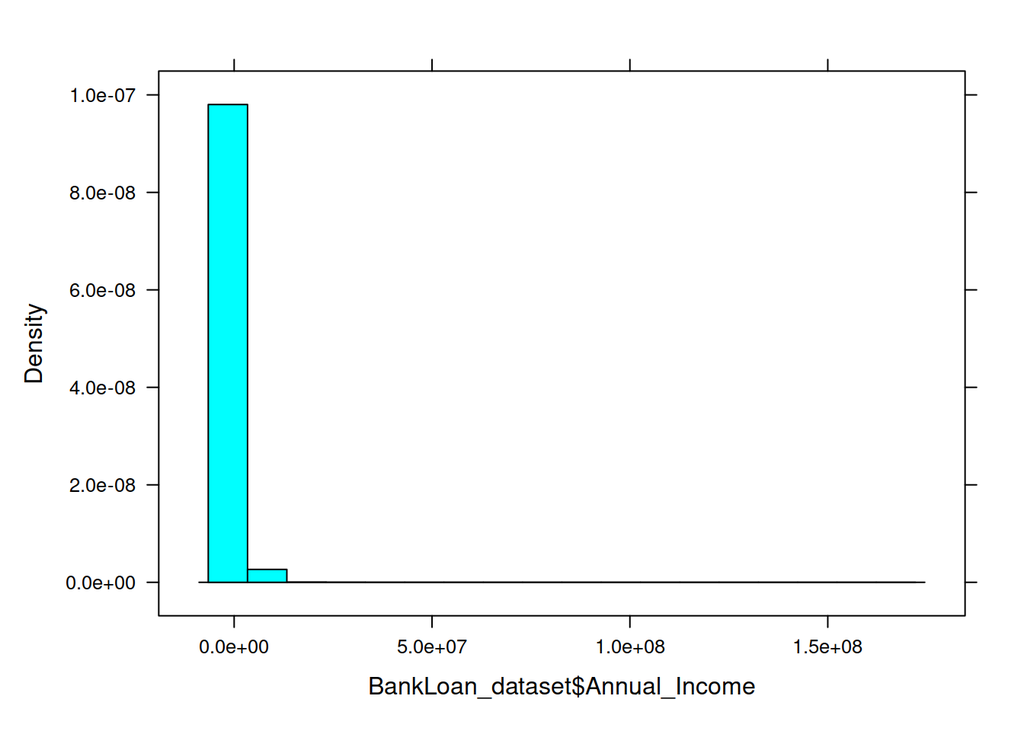

```r
# show outliers before removing them
histogram(BankLoan_dataset$Annual_Income)
```

```r
bankloan <- BankLoan_dataset %>%
  # convert string feature into categorical factors
  mutate_if(is.character, as.factor) %>%

  # remove the nulls
  drop_na() %>%

  ### Remove outliers
  # Annual_Income
  filter(between(Annual_Income,
                 quantile(Annual_Income, 0.25) - 1.5* IQR(Annual_Income),
                 quantile(Annual_Income, 0.75) + 1.5* IQR(Annual_Income))) %>%
  # Current_Loan_Amount
  filter(between(Current_Loan_Amount,
                 quantile(Current_Loan_Amount, 0.25) - 1.5* IQR(Current_Loan_Amount),
                 quantile(Current_Loan_Amount, 0.75) + 1.5* IQR(Current_Loan_Amount))) %>%
  # Credit_Score
  filter(between(Credit_Score,
                 quantile(Credit_Score, 0.25) - 1.5* IQR(Credit_Score),
                 quantile(Credit_Score, 0.75) + 1.5* IQR(Credit_Score))) %>%
  #Number_of_Credit_Problems (there is an outlier of 15)
  filter(between(Number_of_Credit_Problems,
                 quantile(Number_of_Credit_Problems, 0.25) - 1.5* IQR(Number_of_Credit_Problems),
                 4)) %>%
  # Monthly_Debt
  filter(between(Monthly_Debt,
               quantile(Monthly_Debt, 0.25) - 1.5* IQR(Monthly_Debt),
               quantile(Monthly_Debt, 0.75) + 1.5* IQR(Monthly_Debt))) %>%

  # Maximum_Open_Credit
  filter(between(Maximum_Open_Credit,
               quantile(Maximum_Open_Credit, 0.25) - 1.5* IQR(Maximum_Open_Credit),
               quantile(Maximum_Open_Credit, 0.75) + 1.5* IQR(Maximum_Open_Credit))) %>%

  #remove null after filling outliers with NA
  drop_na()

knitr::kable(str(bankloan))
```

```
## 'data.frame':    25185 obs. of  17 variables:
##  $ Loan_Status                 : Factor w/ 2 levels "Charged Off",..: 2 2 2 1 2 2 1 2 2 1 ...
##  $ Current_Loan_Amount         : int  217646 548746 234124 317108 465410 449108 688468 129712 287980 374176 ...
##  $ Term                        : Factor w/ 2 levels "Long Term","Short Term": 2 2 2 1 1 2 1 2 2 1 ...
##  $ Credit_Score                : int  730 678 727 687 688 718 682 723 737 652 ...
##  $ Annual_Income               : int  1184194 2559110 693234 1133274 1722654 1454507 1494616 1465698 1013954 1239199 ...
##  $ Years_in_current_job        : num  1 2 10 8 3 8 1 10 1 10 ...
##  $ Home_Ownership              : Factor w/ 4 levels "HaveMortgage",..: 2 4 4 4 4 2 4 3 2 2 ...
##  $ Purpose                     : Factor w/ 16 levels "Business Loan",..: 4 4 4 4 3 4 4 4 4 10 ...
##  $ Monthly_Debt                : num  10855 18660 14211 9633 15647 ...
##  $ Years_of_Credit_History     : num  19.6 22.6 24.7 17.4 22.3 28.8 16.6 19.4 18.6 36.6 ...
##  $ Months_since_last_delinquent: int  10 33 46 53 30 21 50 6 13 42 ...
##  $ Number_of_Open_Accounts     : int  13 4 10 4 7 14 8 34 11 10 ...
##  $ Number_of_Credit_Problems   : int  1 0 1 0 0 0 0 1 0 0 ...
##  $ Current_Credit_Balance      : int  122170 437171 28291 60287 107559 193990 343995 45106 223117 126350 ...
##  $ Maximum_Open_Credit         : int  272052 555038 107052 126940 488356 458414 843854 163218 489302 415602 ...
##  $ Bankruptcies                : int  1 0 1 0 0 0 0 0 0 0 ...
##  $ Tax_Liens                   : int  0 0 0 0 0 0 0 0 0 0 ...
```

[output not shown]

```r
knitr::kable(summary(bankloan))
```

|  | Loan_Status | Current_Loan_Amount | Term | Credit_Score | Annual_Income | Years_in_current_job | Home_Ownership | Purpose | Monthly_Debt | Years_of_Credit_History | Months_since_last_delinquent | Number_of_Open_Accounts | Number_of_Credit_Problems | Current_Credit_Balance | Maximum_Open_Credit | Bankruptcies | Tax_Liens |
| --- | --- | --- | --- | --- | --- | --- | --- | --- | --- | --- | --- | --- | --- | --- | --- | --- | --- |
|  | Charged Off: 4628 | Min. : 21450 | Long Term : 6672 | Min. :647.0 | Min. : 111245 | Min. : 1.000 | HaveMortgage : 59 | Debt Consolidation:19640 | Min. : 0 | Min. : 3.80 | Min. : 0.00 | Min. : 2.00 | Min. :0.0000 | Min. : 0 | Min. : 0 | Min. :0.0000 | Min. :0.00000 |
|  | Fully Paid :20557 | 1st Qu.:160336 | Short Term:18513 | 1st Qu.:702.0 | 1st Qu.: 882911 | 1st Qu.: 3.000 | Home Mortgage:12444 | other : 1633 | 1st Qu.:10559 | 1st Qu.:14.20 | 1st Qu.: 17.00 | 1st Qu.: 8.00 | 1st Qu.:0.0000 | 1st Qu.: 93841 | 1st Qu.: 231880 | 1st Qu.:0.0000 | 1st Qu.:0.00000 |
|  | NA | Median :259886 | NA | Median :719.0 | Median :1185961 | Median : 6.000 | Own Home : 2175 | Home Improvements : 1555 | Median :15993 | Median :17.40 | Median : 32.00 | Median :10.00 | Median :0.0000 | Median : 170221 | Median : 384648 | Median :0.0000 | Median :0.00000 |
|  | NA | Mean :289590 | NA | Mean :715.1 | Mean :1277038 | Mean : 6.201 | Rent :10507 | Other : 812 | Mean :17067 | Mean :18.64 | Mean : 35.36 | Mean :11.04 | Mean :0.1873 | Mean : 210122 | Mean : 448406 | Mean :0.1241 | Mean :0.02974 |
|  | NA | 3rd Qu.:392436 | NA | 3rd Qu.:734.0 | 3rd Qu.:1580040 | 3rd Qu.:10.000 | NA | Business Loan : 357 | 3rd Qu.:22590 | 3rd Qu.:21.90 | 3rd Qu.: 52.00 | 3rd Qu.:13.00 | 3rd Qu.:0.0000 | 3rd Qu.: 285703 | 3rd Qu.: 613426 | 3rd Qu.:0.0000 | 3rd Qu.:0.00000 |
|  | NA | Max. :789096 | NA | Max. :751.0 | Max. :2960447 | Max. :10.000 | NA | Medical Bills : 312 | Max. :43110 | Max. :70.50 | Max. :176.00 | Max. :48.00 | Max. :4.0000 | Max. :2028877 | Max. :1302114 | Max. :4.0000 | Max. :4.00000 |
|  | NA | NA | NA | NA | NA | NA | NA | (Other) : 876 | NA | NA | NA | NA | NA | NA | NA | NA | NA |

```r
#check if there is null
is.null(bankloan)
```

```
## [1] FALSE
```

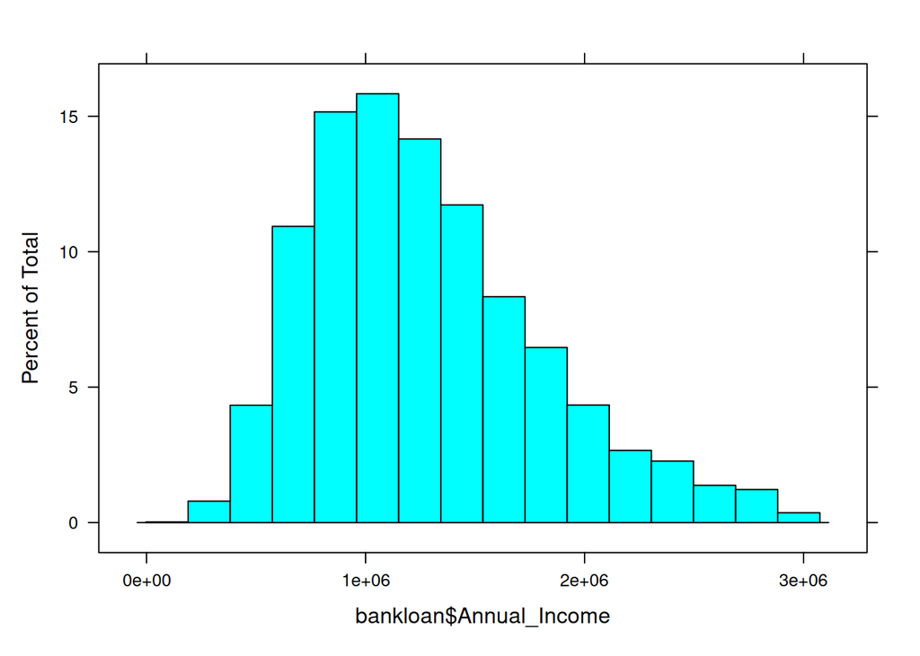

```r
# showing no outliers
histogram(bankloan$Annual_Income)
```

# STEP 3: STATISTICAL SUMMARY

## a) Graphical Summary

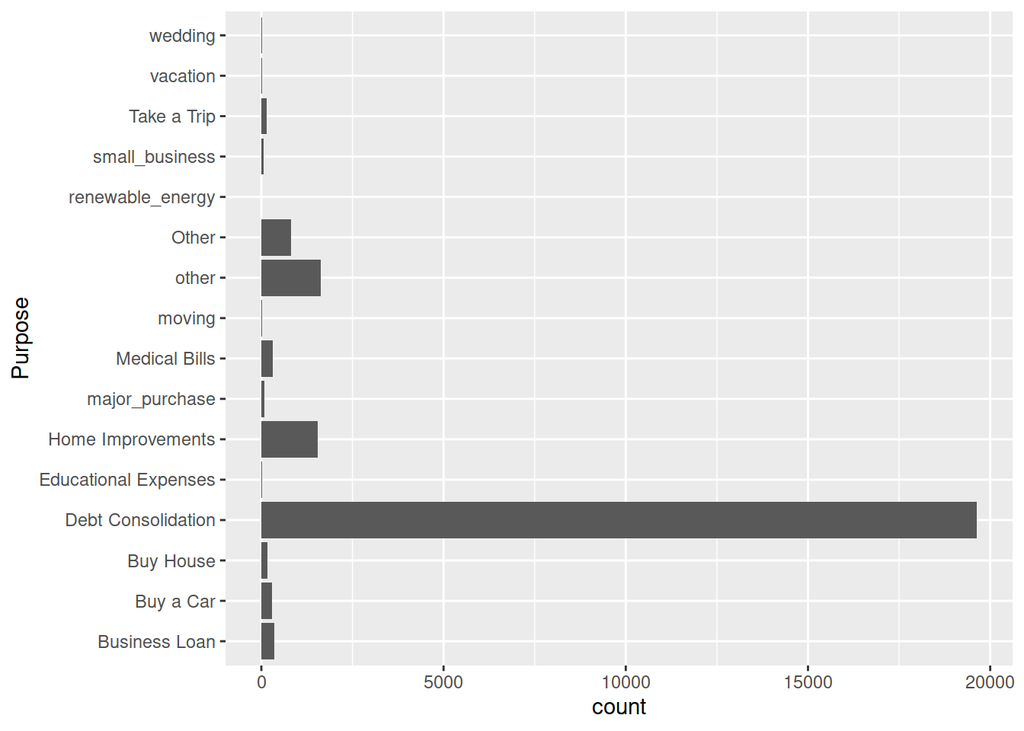

```r
# BAR graph for categorical variables

ggplot(bankloan, aes(x=Purpose)) +
  geom_bar() +
  coord_flip()
```

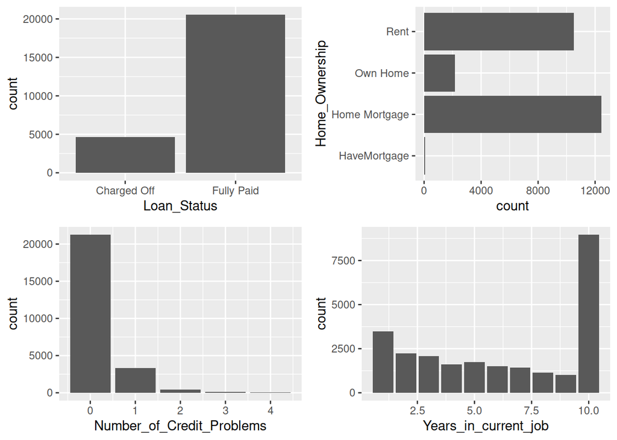

```r
gg_status <- ggplot(bankloan, aes(x=Loan_Status)) +
  geom_bar()

gg_home <- ggplot(bankloan, aes(x=Home_Ownership)) +
  geom_bar() +
  coord_flip()

gg_problem <- ggplot(bankloan, aes(x=Number_of_Credit_Problems)) +
  geom_bar()

gg_job <- ggplot(bankloan, aes(x=Years_in_current_job)) +
  geom_bar()

# arrange multiple plots in one figure
figure <- ggarrange(gg_status, gg_home, gg_problem, gg_job,
                    ncol = 2, nrow = 2,
                    legend="none")
figure
```

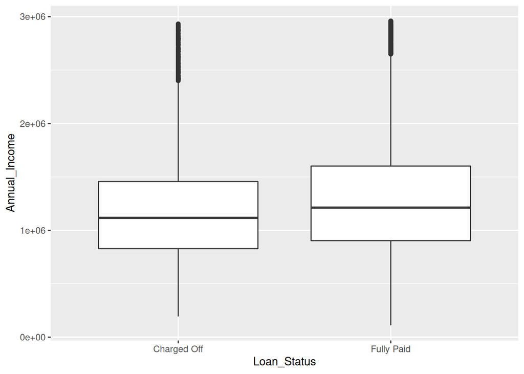

```r
# Boxplot for quantitative variables
ggplot(bankloan, aes(x=Loan_Status, y=Annual_Income)) +
  geom_boxplot()
```

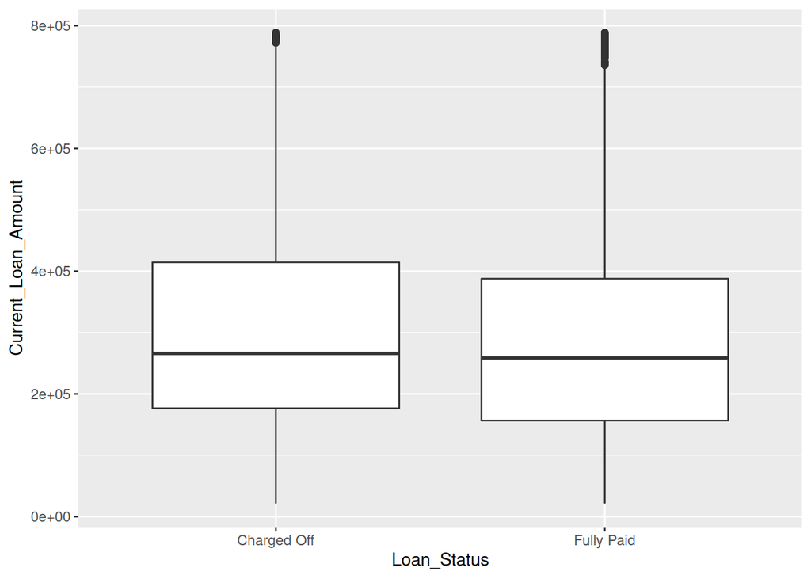

```r
ggplot(bankloan, aes(x=Loan_Status, y=Current_Loan_Amount)) +
  geom_boxplot()
```

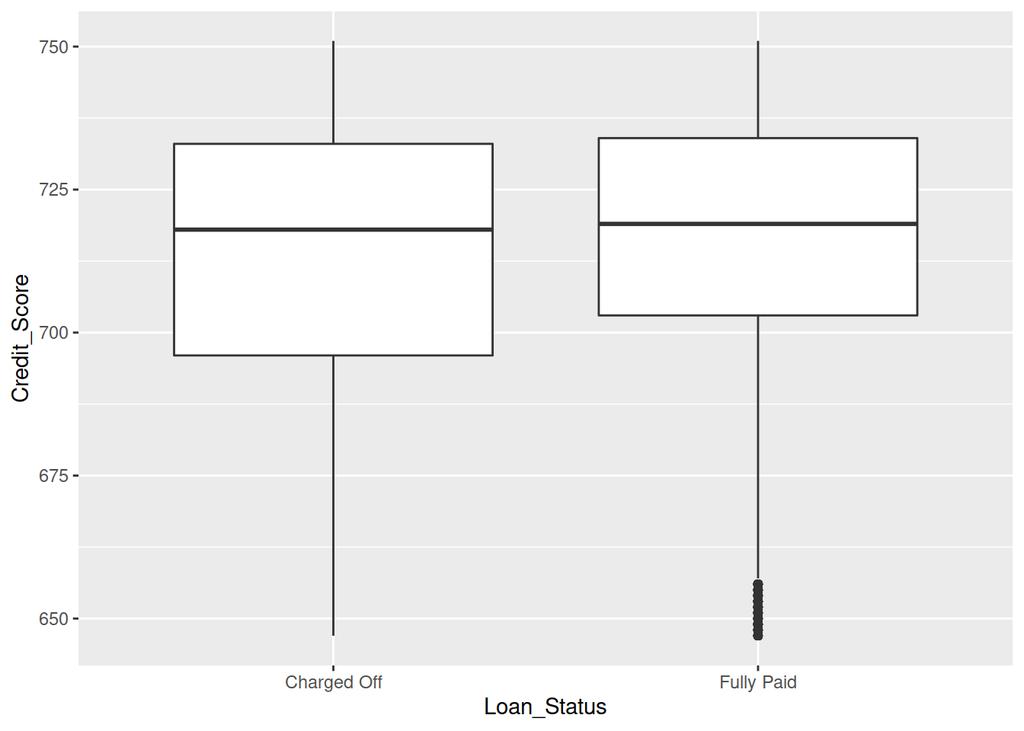

```r
ggplot(bankloan, aes(x=Loan_Status, y=Credit_Score)) +
  geom_boxplot()
```

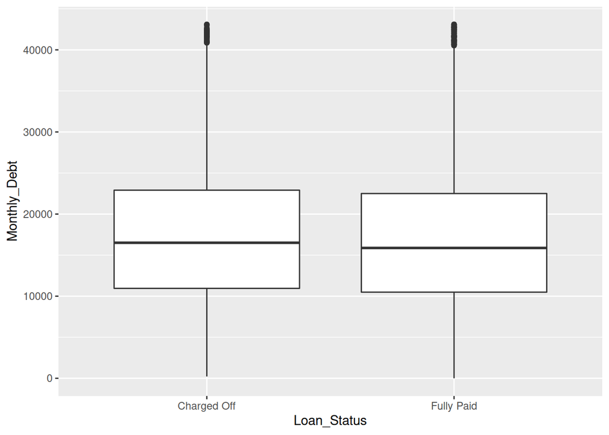

```r
ggplot(bankloan, aes(x=Loan_Status, y=Monthly_Debt)) +
  geom_boxplot()
```

From the Boxplots, comparing annual income, current loan amount, monthly debt and credit score, annual income seems to be the biggest difference between Fully Paid and Charged Off customers.

## b) Numerical Summary

```r
# proportion of Paid-fully and Charged-off
table(bankloan$Loan_Status)
```

```
##
## Charged Off  Fully Paid
##        4628       20557
```

```r
round(prop.table(table(bankloan$Loan_Status)) * 100, 1)
```

```
##
## Charged Off  Fully Paid
##        18.4        81.6
```

```r
# Average group by loan status
# Annual_Income is column5, credit score is column4
aggregate(bankloan[, 4:5], list(bankloan$Loan_Status), median)
```

```
##       Group.1 Credit_Score Annual_Income
## 1 Charged Off          718       1116250
## 2  Fully Paid          719       1212561
```

# STEP 4: IMPLEMENTING Naive Bayes

## a) Using Original Imbalanced Data

```r
set.seed(9650)

# Divide into train and test sets
# Make it dataframe instead of list
indexTrain <- createDataPartition(y=bankloan$Loan_Status, p=0.75, list=FALSE)
training <- bankloan[indexTrain, ]
testing <- bankloan[-indexTrain, ]

# Since there are 26000 of data, take a subset of data for computation efficiency
train_sub <- training[1:1000, ]
test_sub <- testing[1:300, ]


# cross-validation for parameter selection
trainingParameters <- trainControl(method='repeatedcv', number=10, repeats=3)

# Train with nnet. nnet package by default uses the Logistic/Sigmoid Activation function
nb_model <- train(Loan_Status ~ ., train_sub,
                  method='naive_bayes',
                  trControl=trainingParameters,
                  preProcess=c('BoxCox', 'center', 'scale'),
                  na.action=na.omit,
                  trace=FALSE,
                  verbose=FALSE)

# Size: number of hidden layers
# Decay: is the regularization factor that offset overfitting
# Kappa: evaluates the match is significant or by chance
print(nb_model)
```

```
## Naive Bayes
##
## 1000 samples
##   16 predictor
##    2 classes: 'Charged Off', 'Fully Paid'
##
## Pre-processing: Box-Cox transformation (7), centered (32), scaled (32)
## Resampling: Cross-Validated (10 fold, repeated 3 times)
## Summary of sample sizes: 901, 901, 899, 900, 900, 899, ...
## Resampling results across tuning parameters:
##
##   usekernel  Accuracy   Kappa
##   FALSE      0.2093293  0.002821603
##    TRUE      0.7587270  0.001416366
##
## Tuning parameter 'laplace' was held constant at a value of 0
## Tuning
##  parameter 'adjust' was held constant at a value of 1
## Accuracy was used to select the optimal model using the largest value.
## The final values used for the model were laplace = 0, usekernel = TRUE
##  and adjust = 1.
```

```r
# Making predictions on test set, predictor feature is in column 1
prediction <- predict(nb_model, test_sub[-1])
confusionMatrix(prediction, test_sub$Loan_Status)
```

```
## Confusion Matrix and Statistics
##
##              Reference
## Prediction    Charged Off Fully Paid
##   Charged Off           0          0
##   Fully Paid           60        240
##
##                Accuracy : 0.8
##                  95% CI : (0.7502, 0.8438)
##     No Information Rate : 0.8
##     P-Value [Acc > NIR] : 0.5345
##
##                   Kappa : 0
##
##  Mcnemar's Test P-Value : 2.599e-14
##
##             Sensitivity : 0.0
##             Specificity : 1.0
##          Pos Pred Value : NaN
##          Neg Pred Value : 0.8
##              Prevalence : 0.2
##          Detection Rate : 0.0
##    Detection Prevalence : 0.0
##       Balanced Accuracy : 0.5
##
##        'Positive' Class : Charged Off
##
```

## b) IMPROVING PERFORMANCE:

### Using Balanced Data by Downsampling

```r
set.seed(9650)

# Divide data into train and test sets
indexTrain <- createDataPartition(y=bankloan$Loan_Status, p=0.75, list=FALSE)
training <- bankloan[indexTrain, ]
testing <- bankloan[-indexTrain, ]

# Downsampling to balance data
train <- downSample(x=training[, -ncol(training)], y=training$Loan_Status)
test <- downSample(x=testing[, -ncol(testing)], y=testing$Loan_Status)

# Need shuffling data, top half of the data is one class and the bottom half is the other
train <- train[sample(nrow(train)), ]
test <- test[sample(nrow(test)), ]

# Since there are 26000 of data, take a subset of data for computation efficiency
train_sub <- train[1:1000, ]
test_sub <- test[1:300, ]

table(train_sub$Loan_Status)
```

```
##
## Charged Off  Fully Paid
##         499         501
```

```r
table(test_sub$Loan_Status)
```

```
##
## Charged Off  Fully Paid
##         149         151
```

```r
# cross-validation for parameter selection
trainingParameters <- trainControl(method='repeatedcv', number=10, repeats=3)

# Train with nnet, nnet package by default uses the Logistic/Sigmoid Activation function
nb_model <- train(Loan_Status ~ ., train_sub,
                  method='naive_bayes',
                  trControl=trainingParameters,
                  preProcess=c('BoxCox', 'center', 'scale'),
                  na.action=na.omit,
                  trace=FALSE,
                  verbose=FALSE)

# Size: number of hidden layers
# Decay: is the regularization factor that offset overfitting
# Kappa: evaluates the match is significant or by chance
print(nb_model)
```

```
## Naive Bayes
##
## 1000 samples
##   16 predictor
##    2 classes: 'Charged Off', 'Fully Paid'
##
## Pre-processing: Box-Cox transformation (6), centered (32), scaled (32)
## Resampling: Cross-Validated (10 fold, repeated 3 times)
## Summary of sample sizes: 900, 901, 900, 900, 900, 900, ...
## Resampling results across tuning parameters:
##
##   usekernel  Accuracy   Kappa
##   FALSE      0.9098319  0.8188629
##    TRUE      0.8768646  0.7527165
##
## Tuning parameter 'laplace' was held constant at a value of 0
## Tuning
##  parameter 'adjust' was held constant at a value of 1
## Accuracy was used to select the optimal model using the largest value.
## The final values used for the model were laplace = 0, usekernel = FALSE
##  and adjust = 1.
```

```r
# Making predictions on test set, predictor feature is in column 1
nb_prediction <- predict(nb_model, test_sub[-1])
#pred <- predict(nn_model, test_sub[, -c('Loan_Status')])
confusionMatrix(nb_prediction, test_sub$Loan_Status)
```

```
## Confusion Matrix and Statistics
##
##              Reference
## Prediction    Charged Off Fully Paid
##   Charged Off         145          1
##   Fully Paid            4        150
##
##                Accuracy : 0.9833
##                  95% CI : (0.9615, 0.9946)
##     No Information Rate : 0.5033
##     P-Value [Acc > NIR] : <2e-16
##
##                   Kappa : 0.9667
##
##  Mcnemar's Test P-Value : 0.3711
##
##             Sensitivity : 0.9732
##             Specificity : 0.9934
##          Pos Pred Value : 0.9932
##          Neg Pred Value : 0.9740
##              Prevalence : 0.4967
##          Detection Rate : 0.4833
##    Detection Prevalence : 0.4867
##       Balanced Accuracy : 0.9833
##
##        'Positive' Class : Charged Off
##
```

Balancing out the data improves accuracy to 98%, sensitivity to 97% and specificity to 99%. Although Naive Bayes’ algorithm may not need to balance out data, in my case, it helps significantly.

## c) IMPROVING PERFORMANCE:

#### Using Grid

```r
# Define tunning grid
nb_grid <- expand.grid(usekernel = c(TRUE, FALSE),
                       laplace = c(0.01, 0.1, 0.5, 1, 5),
                       adjust = c(0.1, 0.5, 1, 1.5, 2))

trainingParameters <- trainControl(method = 'repeatedcv', number = 10, repeats = 3)

set.seed(9650)
nb_model_grid <- train(Loan_Status~., data = train_sub,
                       method = 'naive_bayes',
                       preProcess = c('BoxCox', 'center', 'scale'),
                       trControl = trainingParameters,
                       tuneGrid = nb_grid)

# Prediction
predictions <- predict(nb_model_grid, data = test_sub)
confusionMatrix(prediction, test_sub$Loan_Status)
```

```
## Confusion Matrix and Statistics
##
##              Reference
## Prediction    Charged Off Fully Paid
##   Charged Off           0          0
##   Fully Paid          149        151
##
##                Accuracy : 0.5033
##                  95% CI : (0.4453, 0.5613)
##     No Information Rate : 0.5033
##     P-Value [Acc > NIR] : 0.5231
##
##                   Kappa : 0
##
##  Mcnemar's Test P-Value : <2e-16
##
##             Sensitivity : 0.0000
##             Specificity : 1.0000
##          Pos Pred Value :    NaN
##          Neg Pred Value : 0.5033
##              Prevalence : 0.4967
##          Detection Rate : 0.0000
##    Detection Prevalence : 0.0000
##       Balanced Accuracy : 0.5000
##
##        'Positive' Class : Charged Off
##
```

## d) Statistical Difference Compared with RF

```r
set.seed(9650)
# Train Random Forest model
rf_model <- train(Loan_Status~., data = train_sub, method = 'rf',
                  preProcess = c('BoxCox', 'center', 'scale'),
                  trControl = trainingParameters)

# Predition using RF model
rf_prediction <- predict(rf_model, data=test_sub)

# t-test to compare if statistically significant
# First, need to convert to numeric for t.test to work
nbPredictions <- as.numeric(nb_prediction)
rfPredictions <- as.numeric(rf_prediction)

t.test(nbPredictions, rfPredictions, conf.level = 0.95, alternative = 'two.sided')
```

```
##
##  Welch Two Sample t-test
##
## data:  nbPredictions and rfPredictions
## t = 0.37429, df = 491.73, p-value = 0.7083
## alternative hypothesis: true difference in means is not equal to 0
## 95 percent confidence interval:
##  -0.05240899  0.07707566
## sample estimates:
## mean of x mean of y
##  1.513333  1.501000
```

```r
t.test(nbPredictions, rfPredictions, alternative = 'less')
```

```
##
##  Welch Two Sample t-test
##
## data:  nbPredictions and rfPredictions
## t = 0.37429, df = 491.73, p-value = 0.6458
## alternative hypothesis: true difference in means is less than 0
## 95 percent confidence interval:
##        -Inf 0.06663537
## sample estimates:
## mean of x mean of y
##  1.513333  1.501000
```

This section is a hypothesis testing to see if Naive Bayes and Random Forest the different performance is statistically significant or is it by chance.

# CONCLUSION AND DISCUSSION

In conclusion, sensitivity was 0% with the original imbalanced data. Although balanced data is not required for Naive Bayes algorithm, in this case it is. Improvement using balanced data gave 98% accuracy, 97% sensitivity and 99% specificity. Tuning grid for hyperparameters does not improve performance further. Hypothesis testing using student t-test shows the difference in performance between Naive Bayes and Random Forest is not statistically significant.

One weakness of this dataset is that, most features (13 out of 17) are numerical. Naive Bayes works with categorical features only. So internally, the algorithm converts each numerical feature into categorical feature by dividing the range into levels or qualtiles. Despite this weakness, it achieve an accuracy of 98%.

In the future, it would be interesting to implement Naive Bayes on other data, such as the Spam and Ham data that you showed in class. I attempted to do that, but my dataset (downloaded from Kaggle) contain text that have special characters and emojis. So when I call the tolower() function, it gave me error. I tried different ways to encode the whole text to different format, but it didn’t help. However, Naive Bayes was simple to implement with the caret package on my bank loan status dataset. But Natural Language Processing (NLP) could be more challenging.